# Measuring MMR using Firesting Oxygen Probe and respR (v2.3.1)

Elliott Schmidt

2023-08-02

Hello! It looks like you have decided on analyzing your respirometry data using the R package respR. Below are some steps that outline how to do so. This specific tutorial is on calculating **maximum metabolic rate**.

Through this tutorial we will be [pipeing](https://r4ds.had.co.nz/pipes.html). The symbol **%>%** and **|>** may be used interchangably.

### Library (packages)

The first step is to **load** all the packages that are needed. Also, before running the code below, make sure that you have **installed** all the packages that are listed. Some packages like *tidyverse* will have a number of dependencies. So while you only have to load one package in reality you are loading several behind the scenes - how exciting!

```r
library("respR")
library("tidyverse")
library("data.table")
library("hms")
library("kableExtra")
```

### Set working directory

Next we will set the working directory. This should always be done in your Rscripts to make sure your files are being saved to the correct location. It can also make it easier to import files. Not sure what directory you’re in. Try using the **getwd()** function.

```r
setwd("[ENTER YOUR WORKING DIRECTORY HERE]")
```

### Enter specimen data

Only some of this data is needed in the analysis, but others are good to include to make sure that you are working with the correct data file. The necessary variables include **mass**, **chamber**, **temperature**, **salinity**, and **chamber_vol**.

```r
FISH_ID = "133.1"
mass = 0.0007676 #in kilograms
chamber = "ch4"
temperature = 28.5
salinity = 35
chamber_vol = 0.04860
system1 = "DELL"
Date1 = "01/07/2023"
```

### Importing data from Firesting

Now we will import our firesting file. There are a couple special notes to make about code that was run above. The code above was imported via the package *readr* which gets loaded when load the *tidyverse* package. This has the benefit of letting you see what the dataframe will look like before importing it and I highly suggest you do this the first time that you import your data. Secondly, you will have to **skip** the first 19 rows from the firesting file as these rows contain metadata, and not the actually oxygen data that you will be using.

```r
firesting <- read_delim("C:/Users/jc527762/OneDrive - James Cook University/PhD dissertation/Data/2023/Resp_backup/2023_Resp/Dell7440/Experiment_ 01 July 2023 11 56AM/Oxygen data raw/firesting.txt",
                             delim = "\t", escape_double = FALSE,
                             col_types = cols(`Time (HH:MM:SS)` = col_time(format = "%H:%M:%S")),
                             trim_ws = TRUE, skip = 19)
```

### Data manipulation

Now that we have the firesting file in R we must manipulate it so that we have only the data that we need.

The first step will be so select only the columns we want. The first three columns that we select and rename as **TIME**, **dTIME**, and **DATE**. The next set of columns that we need are the columns that contain the oxygen data from our chambers which we will rename **ch1**, **ch2**, **ch3**, and **ch4**.

Once we have only the data that we are interested in we will select and reorder the following variables **dTIME**, **chamber** - note this variable will change as we will call upon only the chamber that we have selected in the *specimen data* section - and **TIME**.

Then rename the **chamber** column to **Oxygen**. respR will treat the first column as time data and the second column as oxygen data.

Lastly we make sure that the **dTIME** and **Oxygen** columns are **numeric**.

```r
firesting2 <- firesting %>%
  select(c(1:3,5:8)) %>%
  rename(TIME = `Time (HH:MM:SS)`,
         dTIME = `Time (s)`,
         DATE = Date,
         ch1 = Ch1...5,
         ch2 = Ch2...6,
         ch3 = Ch3...7,
         ch4 = Ch4...8) %>%
  select(c("dTIME", all_of(chamber),"TIME")) %>%
  rename(Oxygen = chamber) %>%
  mutate(dTIME = as.numeric(dTIME),
         Oxygen = as.numeric(Oxygen),
         TIME = as.character(TIME))
```

### Inspect file

The function *inspect()* is a data exploration and preparation function that visualizes respirometry data and inspects it for common issues that may affect the use of further functions in **respR**. More information about the *inspect()* function can be found [here](https://januarharianto.github.io/respR/articles/inspecting.html)

```r
inspect(firesting2)
```

```
## inspect: Applying column default of 'time = 1'
```

```
## inspect: Applying column default of 'oxygen = 2'
```

```
## inspect: Data issues detected. For more information use print().
```

```
##
## # print.inspect # -----------------------
##                 dTIME Oxygen
## numeric          pass   pass
## Inf/-Inf         pass   pass
## NA/NaN           pass   pass
## sequential       pass      -
## duplicated       pass      -
## evenly-spaced    WARN      -
##
## Uneven Time data locations (first 20 shown) in column: dTIME
##  [1]  1  2  3  4  5  6  7  8  9 10 11 15 16 17 18 19 20 21 22 23
## Minimum and Maximum intervals in uneven Time data:
## [1] 0.95 1.54
## -----------------------------------------
```

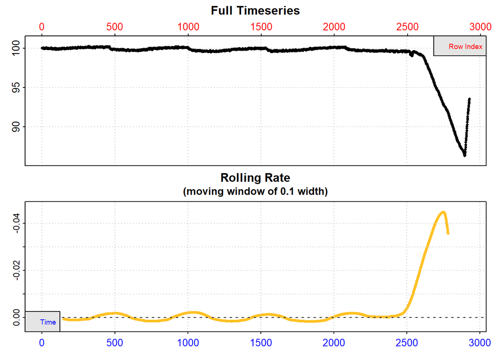

From the output we can see that both our **dTIME** and **Oxygen** columns are numeric, don’t have NA’s or Inf/-inf, values are sequential, and there are no duplicated times, however, it does warn us that are **dTIME** values are not evenly spaced. Firesting recorded value at ~1/sec however sometime is would go slightly slower or faster making the spacing of our values uneven. This is fine, respR will account for this, but it is letting us know.

### Cycle data

**Preamble**: Previously, we imported our firesting file to see what the data looks like. This can be useful if you were unsure which slow was the steepest. However, when calculating **MMR** because we are only concerned with one of the slopes (i.e., the steepest one), we will use the data from our **cycle** data (located in the **All slopes** folder if using AquaResp) to find out when our first cycle started and ended.

When looking at **MMR** we only need to look at the steepest slow which is usually the first, second, or sometimes the third slope. For the example below we will be acting like the first slope was the steepest, which is why we will be importing **cycle1** from our data folder. However, if cycle2 or cycle3 is steepest for your data simply change cycle1 in the code below to cycle2 when importing your data.

In the example below it works best if you use the function **read.csv** to import that data.

#### Importing data

```r
cycle1 <- read.csv("C:/Users/jc527762/OneDrive - James Cook University/PhD dissertation/Data/2023/Resp_backup/2023_Resp/Dell7440/Experiment_ 01 July 2023 11 56AM/All slopes/Cycle_1.txt",
                          sep = ";")
```

Lets find out what time our cycle started and ended (time)

```r
cycle1.start = cycle1[1,1]
cycle1.end = tail(cycle1, n=1)[1,1]
```

Lets find out what row correlates to our starting time

```r
cycle1.start.row <- which(firesting2$TIME == cycle1.start); cycle1.start.row
```

```
## [1] 2585
```

```r
cycle1.end.row <- which(firesting2$TIME == cycle1.end); cycle1.end.row
```

```
## [1] 2885
```

Subset the cycle that we are interested in from our firesting file

```r
cycle1_data <- firesting2 %>%
  subset_data(from = cycle1.start.row,
              to = cycle1.end.row,
              by = "row")
```

```
## subset_data: Multi-column dataset detected in input!
## subset_data is generally intended to subset data already passed through inspect(), or 2-column data frames where time and oxygen are in columns 1 and 2 respectively.
## Subsetting will proceed anyway based on this assumption, but please ensure you understand what you are doing.
```

Lets inspect the data we have

```r
inspect(cycle1_data)
```

```
## inspect: Applying column default of 'time = 1'
```

```
## inspect: Applying column default of 'oxygen = 2'
```

```
## inspect: Data issues detected. For more information use print().
```

```
##
## # print.inspect # -----------------------
##                 dTIME Oxygen
## numeric          pass   pass
## Inf/-Inf         pass   pass
## NA/NaN           pass   pass
## sequential       pass      -
## duplicated       pass      -
## evenly-spaced    WARN      -
##
## Uneven Time data locations (first 20 shown) in column: dTIME
##  [1]  2  3  4  6  7  8  9 10 11 12 13 15 16 18 19 22 23 24 25 26
## Minimum and Maximum intervals in uneven Time data:
## [1] 0.95 1.09
## -----------------------------------------
```

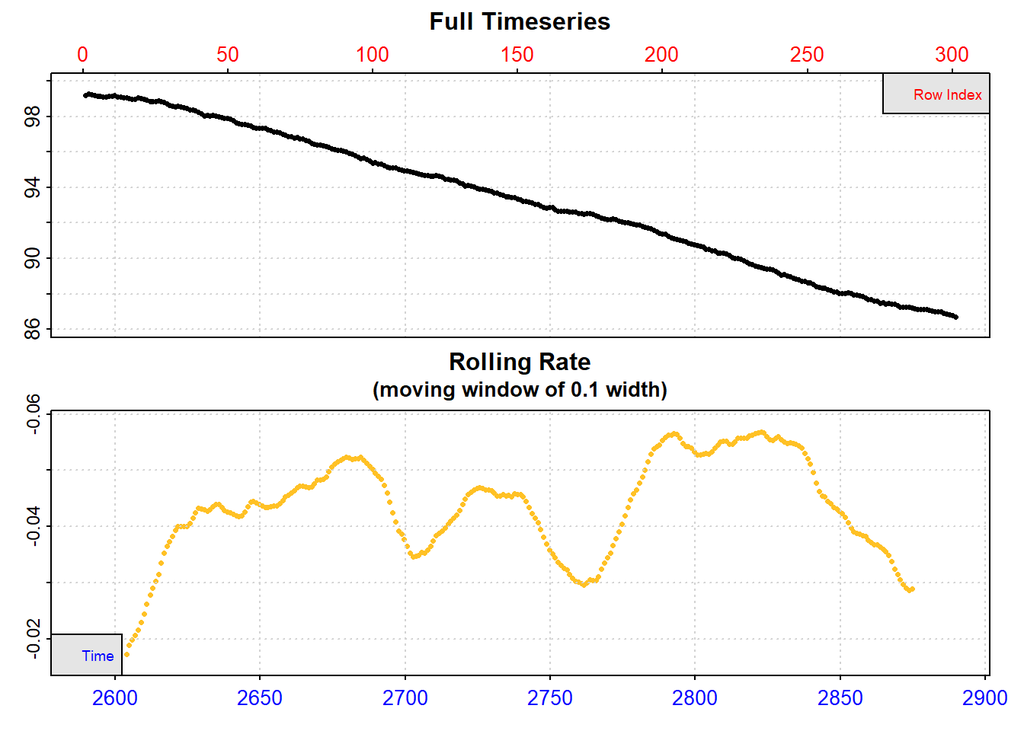

### Calculating MMR

Now we are ready to calculate **MMR**. We need tell respR when all out cycles start and how long they go until. This will be more important when we calculate **RMR**, however, it will be good to practive here.

We will ned to imput our measure, flush, and wait times. I also include a fourth variable called *buffer*, use this variable if you want to add more wait time. This should be used if you think that your wait time during your experiment was not long enough, however the value (time) used for *buffer* should then be extracted from your measure time, so that your overall cycle time does not change.

In the auto rate function the **method** argument can be a number of options. I would look [here](https://januarharianto.github.io/respR/articles/auto_rate) to determine which one best suits your needs. The method that we have chosen in this example *highest* is defined below by the creators of the package:

*Every regression of the specified width across the timeseries is calculated, then ordered using absolute rate values from highest to lowest. This option can only be used when rates all have the same sign, and it essentially ignores the sign. Rates will be ordered from highest to lowest in the $summary table by absolute value regardless of if they are positive or negative.Method is most suitable for when you are looking for the highest rates across a specific time or row window, representative of maximum or active metabolic rates.*

The **width** argument in the *auto_rate()* function refers to the amount of time you want slopes calculated over. Before starting I would run the same piece of data through the auto rate function but with varying widths (e.g., 5, 10, 20, 30, 60, 90, 120) depending on the length of your measure time. Plot these values on a graph and look at the shape of the plot. It will likely by sigmoidal - in this case use the width time that is at the steep section of the sigmoidal curve, this is where variation is most likely to occur.

```
## subset_data: Multi-column dataset detected in input!
## subset_data is generally intended to subset data already passed through inspect(), or 2-column data frames where time and oxygen are in columns 1 and 2 respectively.
## Subsetting will proceed anyway based on this assumption, but please ensure you understand what you are doing.
```

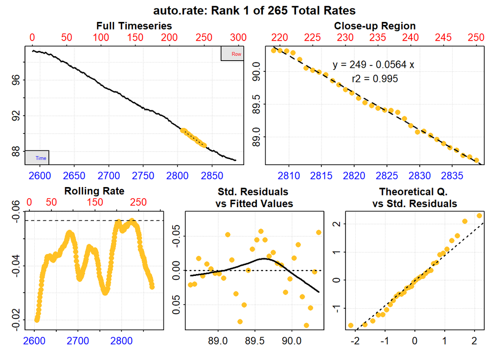

```
##
## # summary.auto_rate # -------------------
##
## === Summary of Results by Highest Rate ===
##      rep rank intercept_b0    slope_b1       rsq density row endrow    time
##   1:  NA    1     249.6388 -0.05672419 0.9954431      NA 219    250 2808.66
##   2:  NA    2     249.2445 -0.05658589 0.9951105      NA 217    248 2806.66
##   3:  NA    3     249.0203 -0.05650605 0.9950410      NA 218    249 2807.66
##   4:  NA    4     248.7968 -0.05642540 0.9950662      NA 220    251 2809.66
##   5:  NA    5     248.5334 -0.05634960 0.9966247      NA 188    219 2777.66
##  ---
## 261:  NA  261     160.6406 -0.02365760 0.9093607      NA   5     36 2594.66
## 262:  NA  262     157.0107 -0.02226637 0.8999686      NA   4     35 2593.66
## 263:  NA  263     154.0278 -0.02112233 0.8950676      NA   3     34 2592.66
## 264:  NA  264     152.2496 -0.02043975 0.8928577      NA   2     33 2591.66
## 265:  NA  265     150.5594 -0.01979026 0.8936702      NA   1     32 2590.66
##      endtime    oxy endoxy        rate
##   1: 2838.66 90.314 88.643 -0.05672419
##   2: 2836.66 90.438 88.717 -0.05658589
##   3: 2837.66 90.416 88.698 -0.05650605
##   4: 2839.66 90.315 88.616 -0.05642540
##   5: 2807.66 92.041 90.314 -0.05634960
##  ---
## 261: 2624.66 99.158 98.444 -0.02365760
## 262: 2623.66 99.196 98.491 -0.02226637
## 263: 2622.66 99.246 98.559 -0.02112233
## 264: 2621.66 99.278 98.577 -0.02043975
## 265: 2620.66 99.212 98.565 -0.01979026
##
## Regressions : 265 | Results : 265 | Method : highest | Roll width : 30 | Roll type : time
## -----------------------------------------
```

```r
buffer = 0
measure = 300
flush = 195
wait = 45

cycle.length = measure + flush + wait
reps <- seq(cycle1.start.row, cycle1.end.row, cycle.length)

starts = reps + buffer
ends = reps + buffer + measure


mmr <- list()
mmr <- subset_data(cycle1_data, from = starts, to = ends, by = "time") %>%
  auto_rate(method = "highest", plot = T, width = 30, by = "time") %>%
  summary()
```

### Calculating background rates

It may be important for your data to determine what the background rate of oxygen use was during your trials. Background oxygen use rates can be calculated via a number of different methods. Because we are measuring MMR we will simply calculate background oxygen use via the background control runs that ran just prior to starting our experiment. However, we will be taking the mean of three background runs, instead of just using one.

There are a number of ways to calculate background rates depending on how background oxygen use was calculated in your experiment. For more information on measuring background oxygen use go [here](https://januarharianto.github.io/respR/articles/adjust_rate.html)

#### Importing background data

Importing background data from cycle files is best down using the *read.csv* option.

```r
pre1 <- read.csv("C:/Users/jc527762/OneDrive - James Cook University/PhD dissertation/Data/2023/Resp_backup/2023_Resp/Dell7440/Experiment_ 01 July 2023 11 15AM/All slopes/Cycle_2.txt",
                   sep = ";")
pre2 <- read.csv("C:/Users/jc527762/OneDrive - James Cook University/PhD dissertation/Data/2023/Resp_backup/2023_Resp/Dell7440/Experiment_ 01 July 2023 11 15AM/All slopes/Cycle_3.txt",
                 sep = ";")
pre3 <- read.csv("C:/Users/jc527762/OneDrive - James Cook University/PhD dissertation/Data/2023/Resp_backup/2023_Resp/Dell7440/Experiment_ 01 July 2023 11 15AM/All slopes/Cycle_4.txt",
                 sep = ";")
```

Optionally you can also import the firesting file associated with your background runs to see if any runs are abnormal. This is often a good idea, so that you can visually inspect your background runs.

```r
firesting_pre <- read_delim("C:/Users/jc527762/OneDrive - James Cook University/PhD dissertation/Data/2023/Resp_backup/2023_Resp/Dell7440/Experiment_ 01 July 2023 11 15AM/Oxygen data raw/firesting.txt",
                           delim = "\t", escape_double = FALSE,
                           trim_ws = TRUE, skip = 19)
```

Once we have imported out background data from three different cycles, we will run the data through a similar data manipulation process that we did before. However we will be running the data through a loop, to condense our code. The data will end up being saved in a list format - in this example the list is called **bg** and we can access the different datasets via indexing.

#### calculating background rates

```r
cycle_list <- list(pre1,pre2,pre3)
bg <- list()

for (i in 1:3) {
  bg[[i]] <- cycle_list[[i]] %>%
    select(c(1:2,4:7))  %>%
    rename(TIME = Time,
           dTIME = Seconds.from.start.for.linreg,
           ch1 = ch1.po2,
           ch2 = ch2.po2,
           ch3 = ch3.po2,
           ch4 = ch4.po2) %>%
    select(c("dTIME", all_of(chamber),"TIME")) %>%
    rename(Oxygen = chamber) %>%
    mutate(dTIME = as.numeric(dTIME),
           Oxygen = as.numeric(Oxygen),
           TIME = as.character(TIME)) %>%
    inspect() %>%
    calc_rate.bg()
}
```

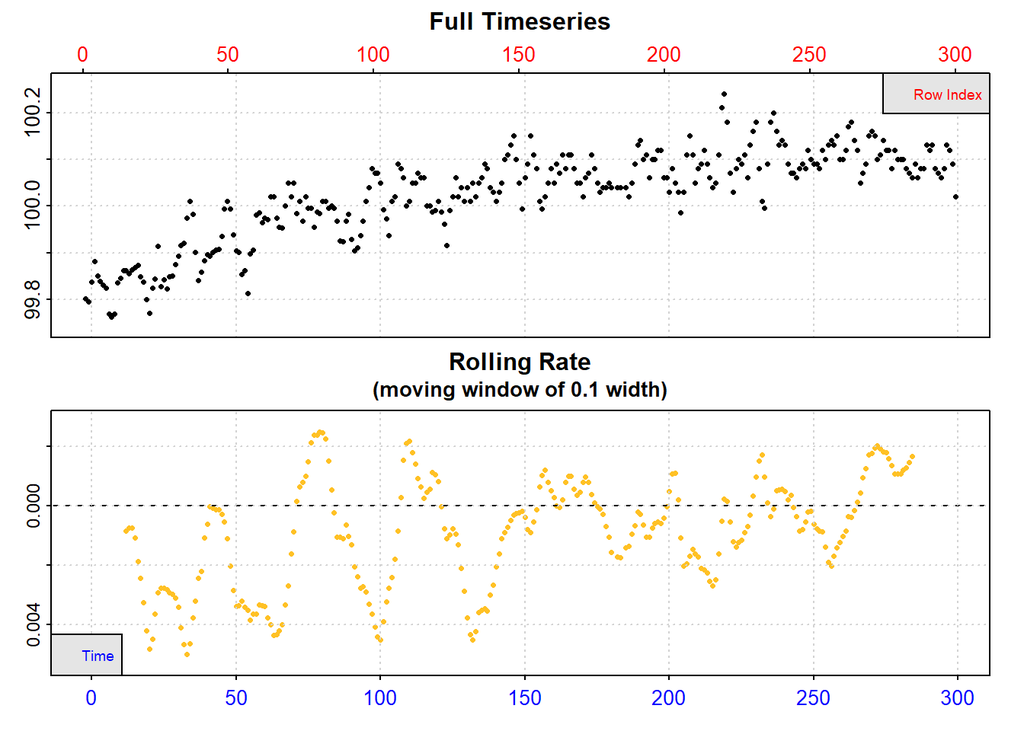

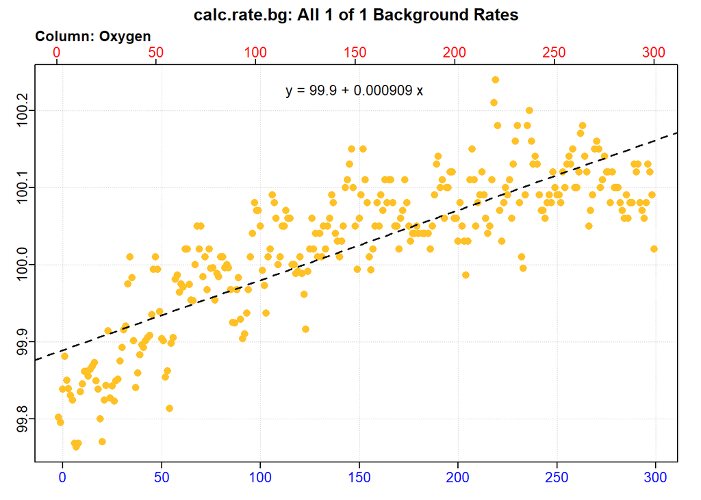

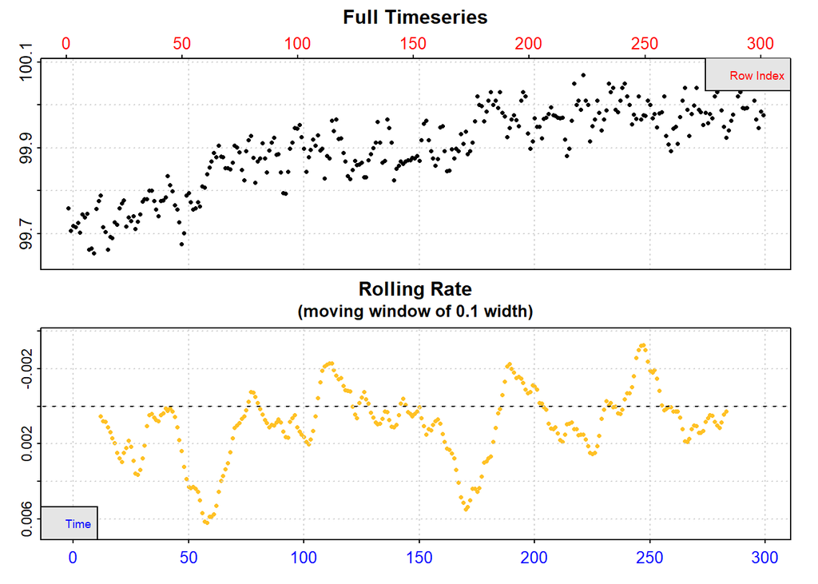

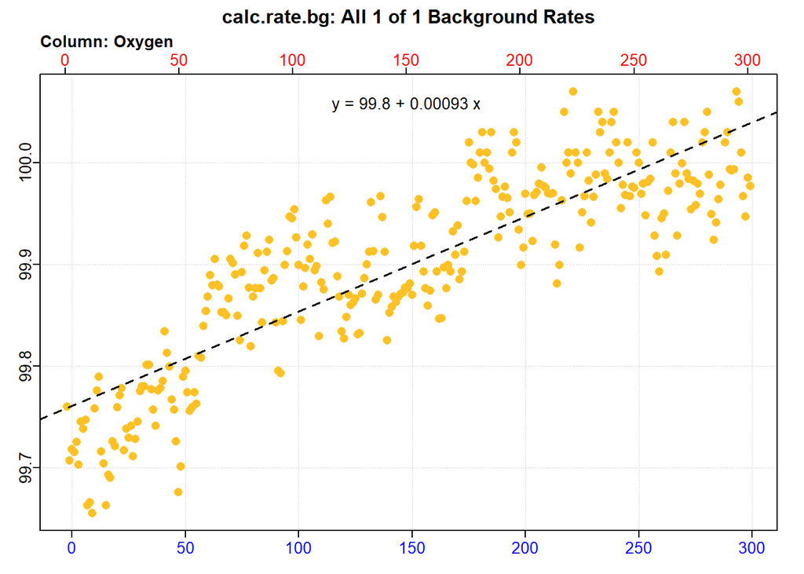

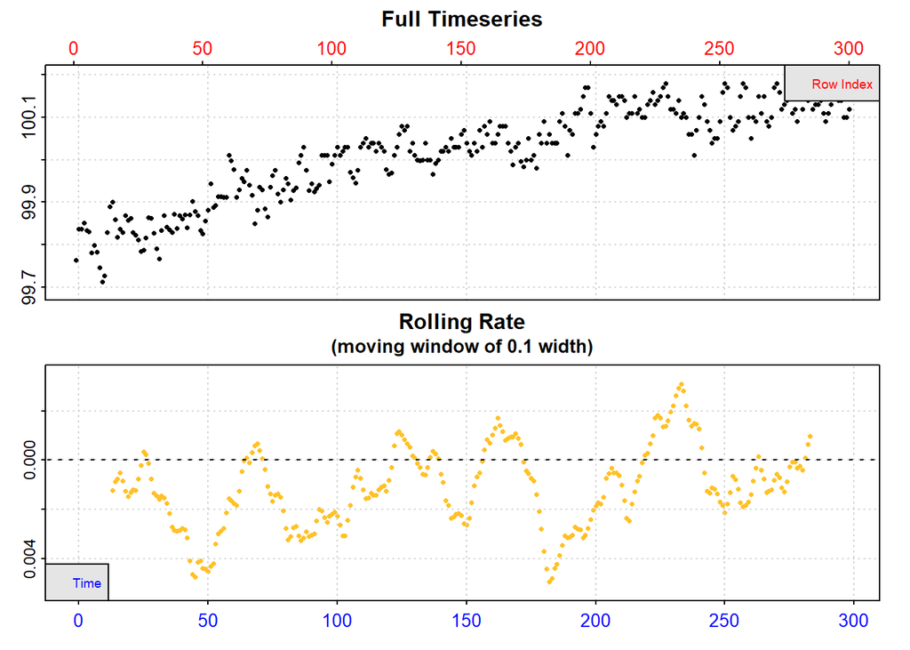

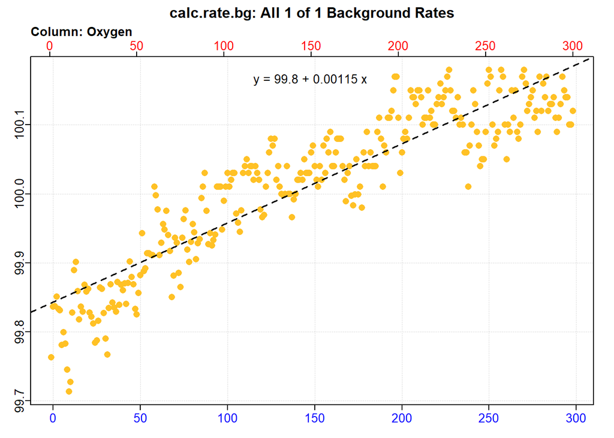

Lets look at the results. We will want to check for any run that looks like an outlier, all three backgournd cycles should have similar values.

```r
bg[[1]]$rate.bg;bg[[2]]$rate.bg;bg[[3]]$rate.bg
```

```
## [1] 0.0009090342
```

```
## [1] 0.0009301265
```

```
## [1] 0.001146474
```

If you are happy with your background rates then we will can move on to adjusting our previously calculated MMR

### Adjusting MMR

Now that we have our background rates we can use them to adjust our previously calculated **MMR** values.

```r
mmr_adj <- adjust_rate(mmr, by=c(bg[[1]]$rate.bg,bg[[2]]$rate.bg,bg[[3]]$rate.bg), method = "mean"); mmr_adj
```

```
## adjust_rate: The 'by' input contains multiple background rates. The mean value will be used to perform adjustments.
```

```
## adjust_rate: Rate adjustments applied using "mean" method.
```

```
##
## # print.adjust_rate # -------------------
## NOTE: Consider the sign of the adjustment value when adjusting the rate.
##
## Adjustment was applied using the 'mean' method.
##
## Rank 1 of 265 adjusted rate(s):
## Rate          : -0.05672419
## Adjustment    : 0.0009952115
## Adjusted Rate : -0.05771941
##
## To see other results use 'pos' input.
## To see full results use summary().
## -----------------------------------------
```

All our calculated **MMR** rates have now been adjusted for background oxygen use

### Converting units

Finally we will want to convert our **MMR** rate data into units that we chose. More information about unit conversion can be found [here](https://januarharianto.github.io/respR/articles/convert_DO.html)

```r
mmr_adj2 <- mmr_adj %>%
  convert_rate(oxy.unit = "%Air",
               time.unit = "secs",
               output.unit = "mg/h/kg",
               volume = chamber_vol,
               mass = mass,
               S = salinity,
               t = temperature,
               P = 1.013253)
```

```
## convert_rate: Object of class 'adjust_rate' detected. Converting all adjusted rates in '$rate.adjusted'.
```

To see a detailed summary of the converted units use the following code below

```r
summary(mmr_adj2)
```

### Selecting rates

Always finished! The last step will be to select which rate you wish to use for your **MMR**. By selecting the method *highest* in our **MMR** calculations, all our rates have been placed in order of highest to lowest - note that by highest rate we mean the lowest number because the rates are negative (-), respR takes this into account (i.e., we are looking for the most negative rate).

Although, we may certain additional requirements, such as our slope needing an **rsq** value greater than 0.95. This can be done by using the *select_rate* function. However, it is important to note that **the order you put the *select_rate* arguments in matters**. In the example below the rates are already ordered highest to lowest. We will then use the *select_rate* function to remove rates that have an **rsq** below **0.95**, then we will select the highest rate.

```
## select_rate: Selecting rates with rsq values between 0.95 and 1...
```

```
## ----- Selection complete. 12 rate(s) removed, 253 rate(s) remaining -----
```

```
## select_rate: Selecting highest 1 *absolute* rate values...
```

```
## ----- Selection complete. 252 rate(s) removed, 1 rate(s) remaining -----
```

```
##
## # plot.convert_rate # -------------------
```

```
## plot.convert_rate: Plotting all rate(s)...
```

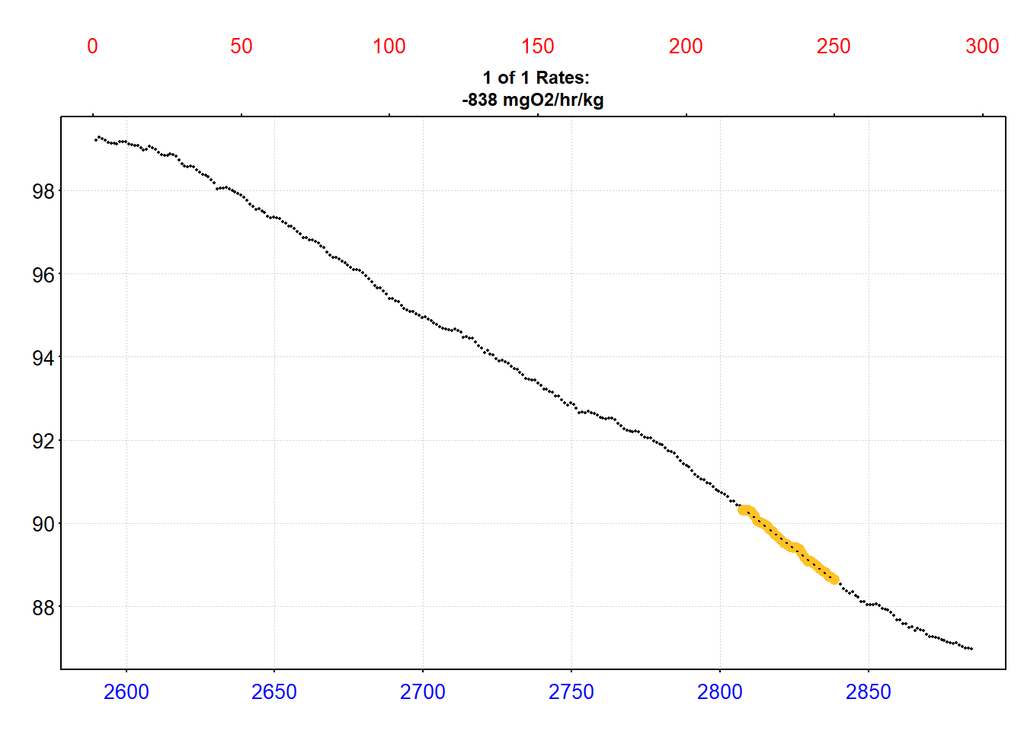

```
## -----------------------------------------
##
## # summary.convert_rate # ----------------
## Summary of all converted rates:
##
##    rep rank intercept_b0    slope_b1       rsq density row endrow    time
## 1:  NA    1     249.6388 -0.05672419 0.9954431      NA 219    250 2808.66
##    endtime    oxy endoxy        rate   adjustment rate.adjusted  rate.input
## 1: 2838.66 90.314 88.643 -0.05672419 0.0009952115   -0.05771941 -0.05771941
##    oxy.unit time.unit volume      mass area  S    t        P   rate.abs
## 1:     %Air       sec 0.0486 0.0007676   NA 35 28.5 1.013253 -0.6432922
##    rate.m.spec rate.a.spec output.unit rate.output
## 1:   -838.0566          NA  mgO2/hr/kg   -838.0566
## -----------------------------------------
```

```r
mmr_final <- mmr_adj2 %>%
  select_rate(method = "rsq", n = c(0.95,1)) %>%
  select_rate(method = "highest", n = 1) %>%
  plot(type = "full") %>%
  summary(export = TRUE)
```

### Results

Lastly, we use all the variables we included at the start as well as out calculated rates to make a nice table that displays our relevant data.

```r
`mmr(mg/h/kg)` <- mmr_final$rate.output *-1
mmr <- mmr_final$rate.output*mass * -1
results <- data.frame(FISH_ID = FISH_ID,
                      Mass = mass,
                      Chamber = chamber,
                      System = system1,
                      Volume = chamber_vol,
                      Date = Date1,
                      Salinity = salinity,
                      Temperature = temperature,
                      `mmr(mg/h/kg)` = `mmr(mg/h/kg)`,
                      mmr = mmr)
knitr::kable(results, "simple")
```

| FISH_ID | Mass | Chamber | System | Volume | Date | Salinity | Temperature | mmr.mg.h.kg. | mmr |
| --- | --- | --- | --- | --- | --- | --- | --- | --- | --- |
| 133.1 | 0.0007676 | ch4 | DELL | 0.0486 | 01/07/2023 | 35 | 28.5 | 838.0566 | 0.6432922 |

**FINISHED!**

Note more infromation can always be found in the outline [respR manual](https://januarharianto.github.io/respR/). Also, don’t forget to cite the package **respR** in your research article (see below):

Harianto J, Carey N, Byrne M (2019). “respR — An R package for the manipulation and analysis of respirometry data.” *Methods in Ecology and Evolution*, 10(6), 912-920. [doi:10.1111/2041-210X.13162](https://doi.org/10.1111/2041-210X.13162.)